# Final BTM 310 Marking Scheme

John Karuitha

7/11/2021

# QUESTION ONE

## PART A

As part of the marketing group at ABC Hotels LTD, you are asked to find out the age distribution of ABC’s clients. With the help of 10 of your colleagues, you conduct exit interviews by randomly selecting people to question at 20 different days. You ask them to tell you if they are younger than 18 years old, 18 to 25 years old, 25 to 35 years old, 35 to 50 years old, or older than 50.

From 470 responses, you find out that 45 are younger than 18, 83 are 18 to 25 years old, 154 are 25 to 35, 18 are 35 to 50, and 170 are older than 50. For the age distribution:

1. Make a frequency table with two columns; Age group and Number. (2 marks)

*The frequency table should be as in Table 1 above (2 marks)*

Age Groups of Customers of ABC Hotel

| age_group | number |
| --- | --- |
| 18 and less | 45 |
| 18-25 | 83 |
| 25-35 | 154 |
| 35-50 | 18 |
| Over 50 | 170 |

2. Make a relative frequency table. (2 Marks)

*The relative frequency should be as in Table 2 above; can either be fractions, decimals or percentages. Accept any of these formats for representing proportions.*

Age Groups of Customers of ABC Hotel

| age_group | prop |
| --- | --- |
| 18 and less | 0.0957447 |
| 18-25 | 0.1765957 |
| 25-35 | 0.3276596 |
| 35-50 | 0.0382979 |
| Over 50 | 0.3617021 |

3. Is Age group Level a quantitative or qualitative variable? Explain. (1 mark)

*Age group is qualitative or categorical as it puts the people into bins or categories and has no units.*

4. Is Number a quantitative or qualitative variable? Explain. (1 marks)

*Number is quantitative and discrete as it has units but cannot take on fractions: NB: The student need NOT say it is discrete, quantitative is enough for full marks.*

5. Draw a bar-graph to represent the above information. (3 marks).

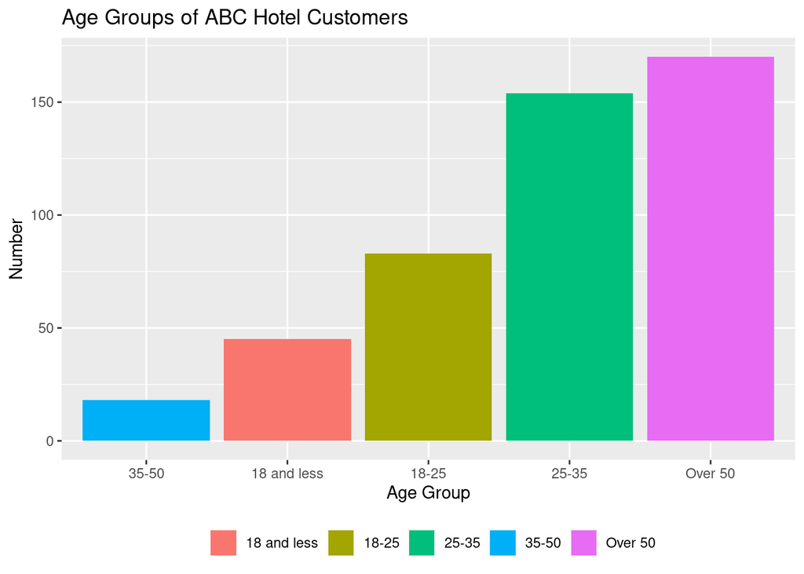

NB: The x-xis should represent age group with number on the y-axis.

*Marks distribution: Getting the chart x and y axis right 1/2 mks Getting the bars right 1 mk. NB: The bars need NOT be ordered in ascending or descending order. The graph need NOT be colored. Titles and axis labels = 1/2 marks*

6. What is the probability that a client of ABC hotel picked at random would be a over 50 years old? (2 mark)

## PART B

According to Akamai’s 2013 State of the Internet report (www.akamai.com/stateoftheinternet/), 35% of observed attack traffic originated from China, 20% from Indonesia, 11% from the US, 5.2% from Taiwan and 2.6% from Russia.

1. Make a bar chart to display the results and label it clearly. (5 marks)

*Marks distribution: Getting the chart x and y axis right 1 mks Getting the bars right 3 mk. NB: The bars need NOT be ordered in ascending or descending order. The graph need NOT be colored. Titles and axis labels = 1 marks*

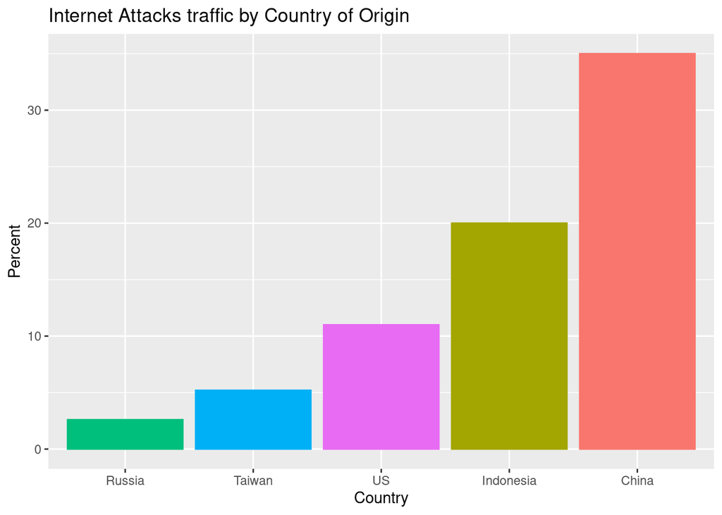

2. Would a pie chart be an effective way of communicating this information? Why or why not? (4 marks)

*NO. The pie chart uses angles to represent data. The human mind is not good at distinguishing angles. The bar graph uses height which the mind easily discerns. The pie chart is especially messy when you have many categories with close values.*

## PART C

You are provided with the following observations regarding the income in a hotel for a week, beginning from a Monday to the following Sunday.

`100, 80, 70, 50, 175, 184, 49`

7. Write a sample R code that you would use to this data. (3 marks)
8. Write a sample R code that you would use to compute the mean of the data. (2 mark)